# 여기도 부동산

# AmesHousing의 집값을 맞춰보자

### 1. 개요

- AmesHousing package내 Ames_raw 데이터를 토대로,  
  여러 변수를 분석하여 집값을 예측하는 모델을 만들기

### 2. 준비

```r
library(AmesHousing)
library(rmarkdown)
library(tidyverse)
```

```r
library(dplyr)
library(ggplot2)
```

### 3. 데이터 둘러보기

- 1. 데이터 규모(행, 열)는?

```r
dim(ames_raw)
```

```
## [1] 2930   82
```

> `소결론` : 열, 즉 변수가 너무 많다.  
> → 어떤 변수가 집값에 어떻게 영향을 줬을지 쉽게 찾기 어려움.  
> → 우선, 집값 자체의 분포를 먼저 살펴 보자.
- 2. 집값의 분포는?

```r
summary(ames_raw$SalePrice)
```

```
##    Min. 1st Qu.  Median    Mean 3rd Qu.    Max.
##   12789  129500  160000  180796  213500  755000
```

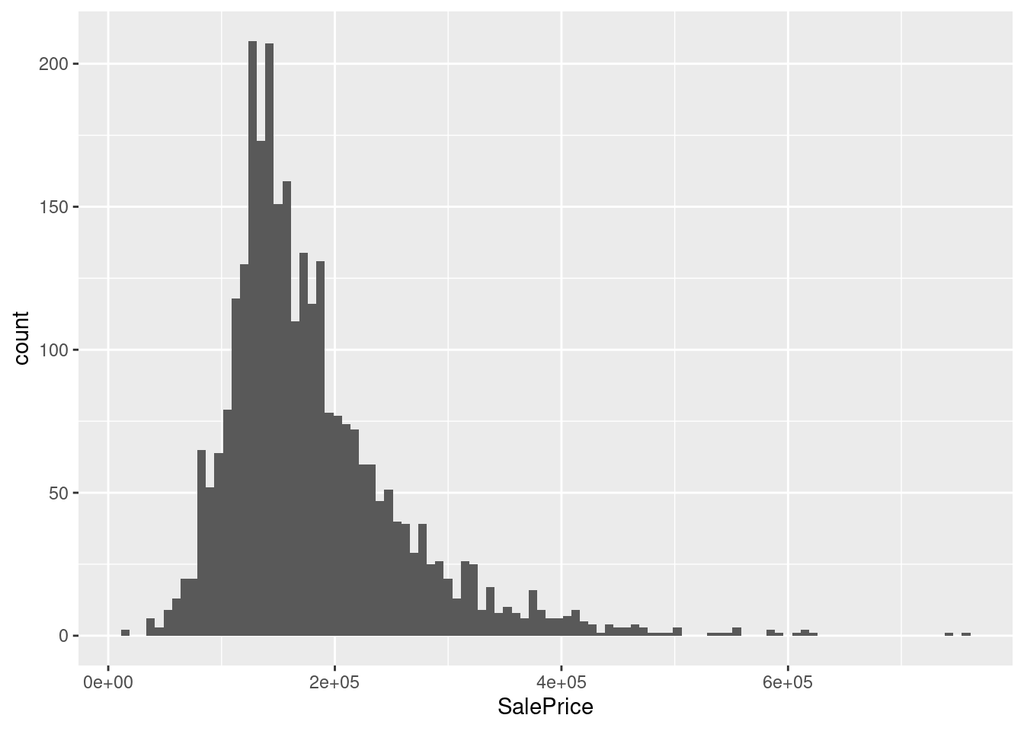

```r
ggplot(ames_raw, aes(x = SalePrice)) +
  geom_histogram(bins=100)
```

### 4. 어떤 변수가 집값에 영향을 주는가?

- 1. **총 변수는 79개\**

     82개 열 중, 종속변수인 SalePrice와 순서인 Order, 식별자인 PID를 제외.
  2. 각 변수를
  - 연속형 변수(예 : `Lot Area`)
  - 분류형 변수(예 : Neighborhood, `Sale Type`)
  - 점수형 변수(예 : `Overall Qual`) 로 나누고,
  3. 분류형 변수는 하위 분류별 집값 평균을 분석 → 하위 분류별 평균 차이가 크지 않으면 해당 변수는 유의미하지 않음
  4. 연속형과 점수형 변수는 집값과 상관도를 분석

  하면 좋겠는데, 변수를 요약하는 코드는 뭘까?
- 일단, 변수가 뭐뭐 있는지 살펴보면,

```r
glimpse(ames_raw)
```

```
## Rows: 2,930
## Columns: 82
## $ Order             <int> 1, 2, 3, 4, 5, 6, 7, 8, 9, 10, 11, 12, 13, 14, 15, 1…
## $ PID               <chr> "0526301100", "0526350040", "0526351010", "052635303…
## $ `MS SubClass`     <chr> "020", "020", "020", "020", "060", "060", "120", "12…
## $ `MS Zoning`       <chr> "RL", "RH", "RL", "RL", "RL", "RL", "RL", "RL", "RL"…
## $ `Lot Frontage`    <int> 141, 80, 81, 93, 74, 78, 41, 43, 39, 60, 75, NA, 63,…
## $ `Lot Area`        <int> 31770, 11622, 14267, 11160, 13830, 9978, 4920, 5005,…
## $ Street            <chr> "Pave", "Pave", "Pave", "Pave", "Pave", "Pave", "Pav…
## $ Alley             <chr> NA, NA, NA, NA, NA, NA, NA, NA, NA, NA, NA, NA, NA, …
## $ `Lot Shape`       <chr> "IR1", "Reg", "IR1", "Reg", "IR1", "IR1", "Reg", "IR…
## $ `Land Contour`    <chr> "Lvl", "Lvl", "Lvl", "Lvl", "Lvl", "Lvl", "Lvl", "HL…
## $ Utilities         <chr> "AllPub", "AllPub", "AllPub", "AllPub", "AllPub", "A…
## $ `Lot Config`      <chr> "Corner", "Inside", "Corner", "Corner", "Inside", "I…
## $ `Land Slope`      <chr> "Gtl", "Gtl", "Gtl", "Gtl", "Gtl", "Gtl", "Gtl", "Gt…
```

[output cut: 69 more lines]

- 이 중 의미를 유추해볼 수 있는 몇 개의 변수를 뽑아서 집값 박스그래프를 보면,
  - 분류형 변수(예 : `House Style`, `Sale Type`)
  - 점수형 변수(예 : `Overall Qual`)
- 1. `House Style` 별 분포

```r
ames_raw %>%
  group_by(`House Style`) %>%
  summarize(mean(SalePrice, na.rm = TRUE))
```

```
## # A tibble: 8 x 2
##   `House Style` `mean(SalePrice, na.rm = TRUE)`
##   <chr>                                   <dbl>
## 1 1.5Fin                                137530.
## 2 1.5Unf                                109663.
## 3 1Story                                178700.
## 4 2.5Fin                                220000
## 5 2.5Unf                                177158.
## 6 2Story                                206990.
## 7 SFoyer                                143473.
## 8 SLvl                                  165527.
```

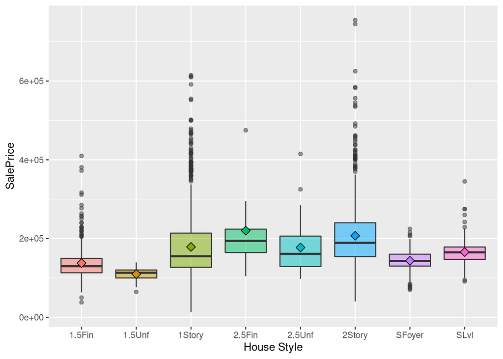

```r
ggplot(ames_raw, aes(x = `House Style`, y = SalePrice, fill=`House Style`)) + geom_boxplot(alpha=0.5,show.legend = TRUE) +
  theme(legend.position="none") + stat_summary(geom='point',fun=mean,shape=23,size=3)
```

- 2. `Sale Type` 별 분포

```r
ames_raw %>%
  group_by(`Sale Type`) %>%
  summarize(mean(SalePrice, na.rm = TRUE))
```

```
## # A tibble: 10 x 2
##    `Sale Type` `mean(SalePrice, na.rm = TRUE)`
##    <chr>                                 <dbl>
##  1 "COD"                               132248.
##  2 "Con"                               224446
##  3 "ConLD"                             125748.
##  4 "ConLI"                             180106.
##  5 "ConLw"                             121938.
##  6 "CWD"                               184238.
##  7 "New"                               275751.
##  8 "Oth"                               114920.
##  9 "VWD"                               137000
## 10 "WD "                               174362.
```

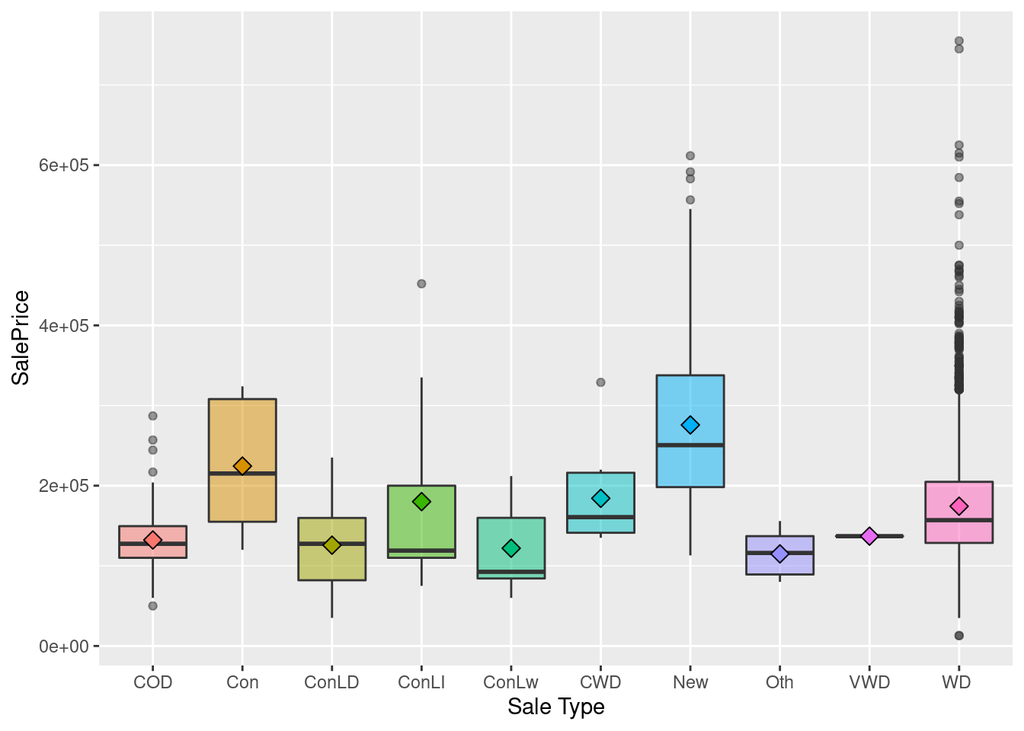

```r
ggplot(ames_raw, aes(x = `Sale Type`, y = SalePrice, fill=`Sale Type`)) + geom_boxplot(alpha=0.5,show.legend = TRUE) +
  theme(legend.position="none") + stat_summary(geom='point',fun=mean,shape=23,size=3)
```

- 3. `Overall Qual` 별 분포

```r
ames_raw %>%
  group_by(`Overall Qual`) %>%
  summarize(mean(SalePrice, na.rm = TRUE))
```

```
## # A tibble: 10 x 2
##    `Overall Qual` `mean(SalePrice, na.rm = TRUE)`
##             <int>                           <dbl>
##  1              1                          48725
##  2              2                          52325.
##  3              3                          83186.
##  4              4                         106485.
##  5              5                         134753.
##  6              6                         162130.
##  7              7                         205026.
##  8              8                         270914.
##  9              9                         368337.
## 10             10                         450217.
```

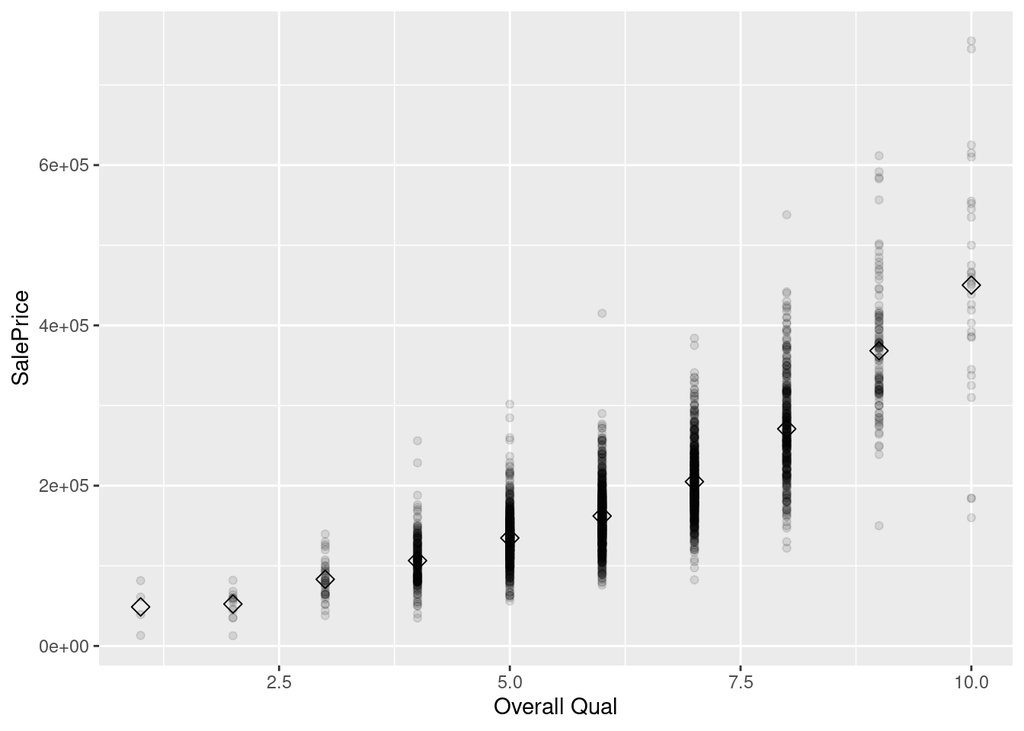

```r
ggplot(ames_raw, aes(x =`Overall Qual`, y = SalePrice)) +
  geom_point(alpha=0.1) +
   stat_summary(geom='point',fun=mean,shape=23,size=3)
```

### 5. 더 해보고 싶은 것

- 깃허브 연결하면 왜 마크다운이 안되는가…
- 전체 변수를 종류별로 뽑아내는 방법은? : select를 어떻게 잘 쓰면 될지도.
- 변수별 통계(피벗테이블)

[output not shown]

### 6. 집값 맞추기

- 언젠간 되겠지?